Importance / Relation to Overall Question: You would think that height would affect the performance of Canoeing Sports, as taller someone is, the more likely they are to have long, strong strokes.

```
## # A tibble: 108 x 3
## # Groups:   Event [27]
##    Event                                          Medal        n
##    <chr>                                          <chr>    <int>
##  1 Canoeing Men's Canadian Doubles, 1,000 metres  Bronze      38
##  2 Canoeing Men's Canadian Doubles, 1,000 metres  Gold        38
##  3 Canoeing Men's Canadian Doubles, 1,000 metres  No Medal   354
##  4 Canoeing Men's Canadian Doubles, 1,000 metres  Silver      38
##  5 Canoeing Men's Canadian Doubles, 10,000 metres Bronze       8
##  6 Canoeing Men's Canadian Doubles, 10,000 metres Gold         8
##  7 Canoeing Men's Canadian Doubles, 10,000 metres No Medal    36
##  8 Canoeing Men's Canadian Doubles, 10,000 metres Silver       8
##  9 Canoeing Men's Canadian Doubles, 500 metres    Bronze      18
## 10 Canoeing Men's Canadian Doubles, 500 metres    Gold        18
## # … with 98 more rows
```

```
##  (Intercept)       Height
## -0.728978886  0.006187414
```

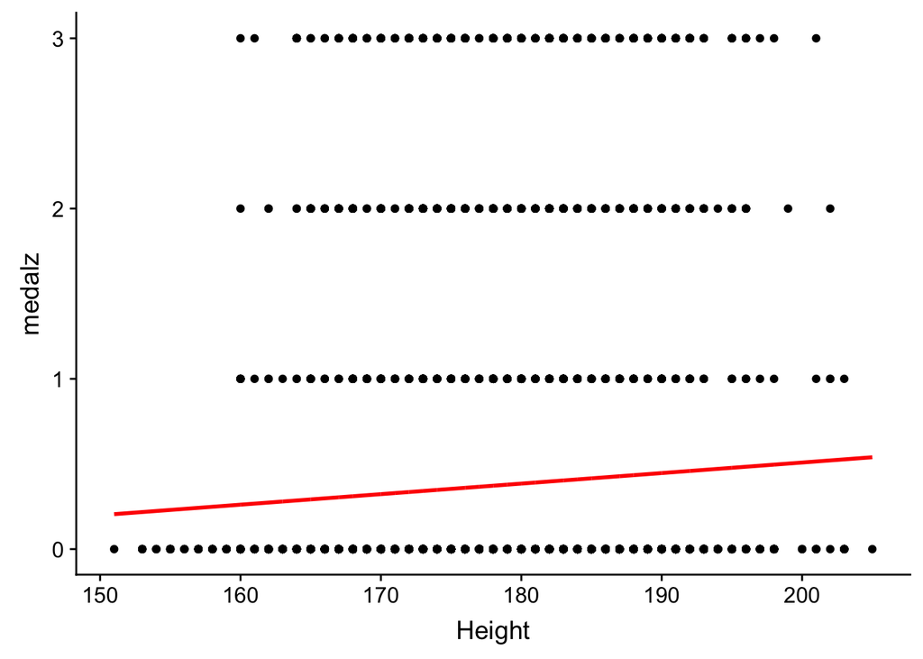

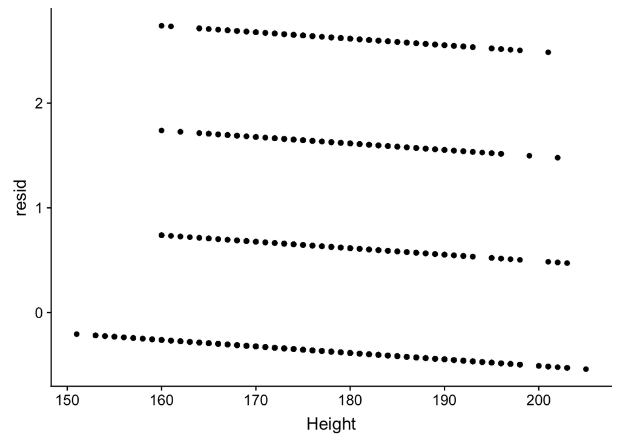

Findings: There is a slight positive correlation between performance and height, so we can kind of conlcude that ones height might slighlty impact their performance. This direclty answers the main question by suggesting that there might be a poor correlation between height and performing better in the olympics.

New Tools: I used data_grid, add_predictions, lm, and ifelse statements

### Arie’s Section

Subquestion: Does a country do better or worse depending on the season of the olympics?

Importance/ elation to Overall Question:: This Question is important and interesting because countries will be able to understand which season they do better in. This will help them improve during their weak season.

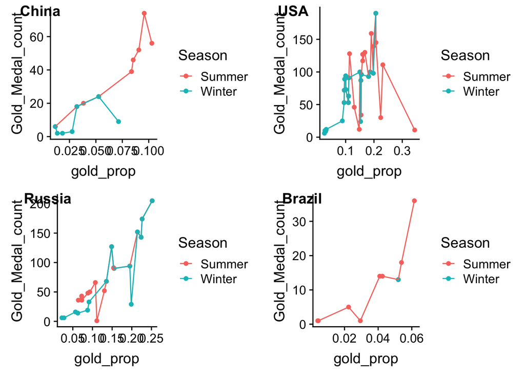

```
##
## Call:
## lm(formula = Gold_Medal_count ~ gold_prop, data = df)
##
## Coefficients:
## (Intercept)    gold_prop
##       31.86       346.59
```

```
##
## Call:
## lm(formula = Gold_Medal_count ~ gold_prop, data = df)
##
## Coefficients:
## (Intercept)    gold_prop
##      -6.136      606.551
```

```
##
## Call:
## lm(formula = Gold_Medal_count ~ gold_prop, data = df)
##
## Coefficients:
## (Intercept)    gold_prop
##       -30.5        798.8
```

```
##
## Call:
## lm(formula = Gold_Medal_count ~ gold_prop, data = df)
##
## Coefficients:
## (Intercept)    gold_prop
##      -4.118      432.732
```

Findings: Since there were so many countires, I focused on places with different climates (USA, Russia, China, and Brazil). The grapphs above show that warmer climate countries perform better in the summer, coolor climate countires perform better in the winter. This answers my quesiton, “Does a country do better or worse depending on the season of the olympics?” This relates to the overall quesiton because, this shows countries with warner climates have an advantage in the summer and countries with cooler climates have the advantage in the winter.

New Tools: I used `plot_grid()`, `map()`, `nest()`, `lm()`.

### Lab 2 Reflections

- Team: At the begging of the semester our goals were “We aspire to enhance our technical, communication, and project management skills. We also aspire to be a rad team but not team number one.” We think we did a pretty good job in meeting our goals. If we could travel back in time we would tell our team to keep being rad, meet up more often, and start discussing reading materials before taking the irat and trat.
- Ethan: After learning much more about the data science field, my 6-month goal after graduation has changed as it may not be necessary for me to get a master’s degree in data science. I hope to gain enough knowledge and experience through my major, online self learning, and internships to become a data scientst soon after I graduate. My 5 year goal has not changed as I still hope to travel and work in the big city! I learned so much R in this course and it has further ignited my confidence and my passion for data science. If I were go go back to the beginning of the semester, I’d tell myself to keep working on personal projects so I can enhance my skills quickly.
- David (big gey):
- Ryan: My 6 month goal after graduating was wantint to find a job as a data scientist. This did not really change. My 5 years goal after graduating wanting to be working remotely and traveling. This also did not really change. I learned base R, for the most part. I also learned a little bit more about what it’s like to work on a team. Oh and I learned gitKraken. If I could give myself advice, it would be to start aksing more quesiton, keep studying more for the tRats, and stop second guessing yourself.
- Arie: After taking this class, my 6-month and 5 year goal still remains the same. However, I think I want to start working on my buisness plan as I secure a data science job. I learned so much in this class! I’ve never programmed before, and now I can do some programming in R. I learned about permuation tests. If I were to go back and give myself advice, I would tell myself to do all the readings and exercises thoroughly, and practice R more outside of class.
- Anderson: After learning a lot about the basic functions and format in the data science field my 6-month goal has changed. I will try to minor if not major in the data sience field and learn as many useful and necessary languages to compute and tidy data. My 5 year goal has remained somewhat the same. I still plan on living in the city and hope to have a fulfilling job. Throughout this entire course I have gained lots of knowledge on computing and feel comfortable with the language of R. If I could go back and give myself advice it would be to review the material and practice each chapter on my own.

### Who Did What

- Ethan: Individual section, helped other ind. sections, formatting
- David (big gey):
- Ryan: ind section
- Arie: in section, team findings/conclusion, recomendations, team reflection
- Anderson: Individual section, tidying